# Detekce mluvené řeči v jazyce R

Závěrečná práce z předmětu Pokročilé metody statistiky. Práce byla vypracována ve vývojovém prostředí RStudio.

### Prototyp chytrého řešení pro pomoc lidem se sluchovým postižením

Detekce řečové aktivity hraje velmi důležitou roli v oblasti zpracování mluvené řeči. Detektory řečové aktivity jsou využívány v mnoha různých oblastech vědy, ale dnes i v průmyslových aplikacích. Detektory řečové aktivity jsou používány v průběhu rozpoznávání řeči nebo v algoritmech zvýrazňování řeči. Jiné aplikace mohou být z oblasti komunikace. Podobný přístup řeší VoIP, kde detektory řečové aktivity slouží pro snížení nutné přenosové kapacity. To je dosaženo nepřenášením paketů obsahujících ticho. Bylo také ukázáno, že detektory řečové aktivity mohou přispět k zvětšení efektivity rozpoznávání řeči.

Rozpoznávání mluvené řeči je ve vyvíjeném prototypu rozděleno na dva kroky. První krok se odehrává na klientovi a druhá část na serveru. Před implementací serverové části byla provedena analýza veřejně dostupných technologii pro zpracování zvuku. Jako vhodná technologie byla vybrána služba postavená na platformě Google Cloud. Jedná se o řešení Google Cloud Speech API. Pro začátek výzkumu je naprosto dostačující. Dalším krokem bude testování konkurentní služby od společnosti IBM. Jedná se o službu IBM Watson Speech To Text.

### Aktustické vnímání řeči

Člověk je schopen vnímat zvuky v rozsahu kmitočtů od přibližně 20 Hz do 20 kHz a v rozsahu intenzity cca 0 až 130 dB (tzv. plocha slyšení). Normální řeč však leží v podstatně užším pásmu - přibližně mezi 180 Hz až 6 kHz a 30 až 80 dB. Dobrá srozumitelnost se dosáhne při přenosu řeči v pásmu od 300 Hz do 5 kHz. Pro nejběžnější konverzaci stačí dokonce přenos v pásmu od 300 do 2,5 kHz.

### Problémy rozpoznávání řeči

Úloha rozpoznávání řeči se potýká s mnoha problémy, které vyplývají ze samotné povahy lidské řeči. Ve chvíli kdy člověk mluví, nikdy nevysloví stejné slovo dvakrát totožným způsobem. Je to ovlivněno mnoha faktory. Jedná se o zdůrazňování slov, odlišné vyslovování slov na začátku a na konci věty, různé melodie různých typů vět (oznamovací vs. tázací), vliv předchozích a následujících slov ve větě, emoce, náladu, případně zdravotní stav člověka. Problémy mohou nastat též při určování hranic mezi slovy. Člověk nevyslovuje slova jako zřetelně oddělené jednotky, slova naopak úzce navazují a např. neslabičné předložky splývají s jiným slovem úplně. Akustická informace bývá nedostatečná a zpravidla je potřeba využít kontextu slov a dodat hlubší jazykové znalosti – syntaktické, případně sémantické. Programy, které si kladou za cíl rozpoznávat spontánní mluvenou řeč, se musejí vypořádat se skutečností, že struktura spontánní řeči se značně liší od čtení připraveného textu, která má co do jazykové struktury spíše povahu psaného slova. Věty vyslovené v rámci spontánního projevu často neodpovídají syntaktickým pravidlům jazyka. Projevuje se v nich koktání, zadrhávání, opakování slov, slovní doplňky, věty mohou být neúplné. Je tedy zřejmé, že problematika detekce chyb v automatickém přepisu řeči je aktuální. Označování problematických úseků přepisu může být využito např. pro vylepšení dialogových systémů. Jedná se o počítačové systémy, které poskytují člověku informace na základě hlasové komunikace, zpravidla telefonicky.

### Princip HMM

Detekce probíhá na základě modelování částí řeči pomocí jednoho nebo i více HMM. Jeden model většinou odpovídá úsekům řeči a druhý úsekům šumového pozadí. Bude použit pojem dlouhodobý a krátkodobý segment. Z krátkodobého segmentu řeči je vypočítán jeden vektor parametrů. Pojmem dlouhodobý segment se myslí posloupnost vektorů parametrů. V dlouhodobých segmentech stejné nebo rostoucí délky se provádí výpočet pravděpodobnosti, zda HMM generuje příslušný úsek šumu nebo řeči. Výstupem jsou vektory pravděpodobností příslušné ke každému řečovému rámci. Je-li použit pouze jeden model – model šumu, může být prahována přímo tato pravděpodobnost. Jsou-li použity dva modely – model šumu i model řeči, jsou pravděpodobnosti nejprve vzájemně odečteny a výsledný rozdíl je prahován. Tyto vektory, které jsou prahovány, jsou označeny jako kriteriální funkce.

### Práce s jazykem R

Pro práci se zvukovými stopami jsou využívány knihovny

- **audio** (rozhraní pro zvuková zařízení umožňuje přehrávání zvukové stopy),
- **TuneR** (knihovna dokáže analyzovat hudbu a řeč, dokáže pracovat s různými typy zvukových souborů, jako např. mp3, midi, wav),
- **SeeWave** (knihovna nabízí funkce pro analýzu, manipulaci, zobrazení, editování a syntézu zvuku),
- **HMM** (knihovna určená k nastavení, aplikování a vyvozování závěrů pomocí Skrytých Markovových modelů).

```r
install.packages("audio")
install.packages("tuneR")
install.packages("seewave")
install.packages("HMM")
```

```r
library(audio)
```

Pro ukázku, jakým způsobem se pracuje se zvukovou stopou a co knihovny nabízejí

Pokud vznikl u přehrávání problém je nutné vykonat následující příkaz. Jedná se ochybu `Error in play.default(zvuk) : long vectors not supported yet: au.c:137`

```r
setWavPlayer('/usr/bin/afplay')
```

```
Error in setWavPlayer("/usr/bin/afplay") :
  could not find function "setWavPlayer"
```

Jedná se o využití výchozího zvukového přehrávače. V případě MacOS je možné přenastavit takto.

Klasické vykreslení jedná zvukové křivky o délce 3,5s.

[figure not shown]

Vypsání definice objektu zvukové stopy.

```r
print(song)
```

```
Wave Object
    Number of Samples:      55911
    Duration (seconds):     3.49
    Samplingrate (Hertz):   16000
    Channels (Mono/Stereo): Mono
    PCM (integer format):   TRUE
    Bit (8/16/24/32/64):    16
```

Funkce vykresluje frekvenční spekturum (relativní amplituda různých frekvencí).

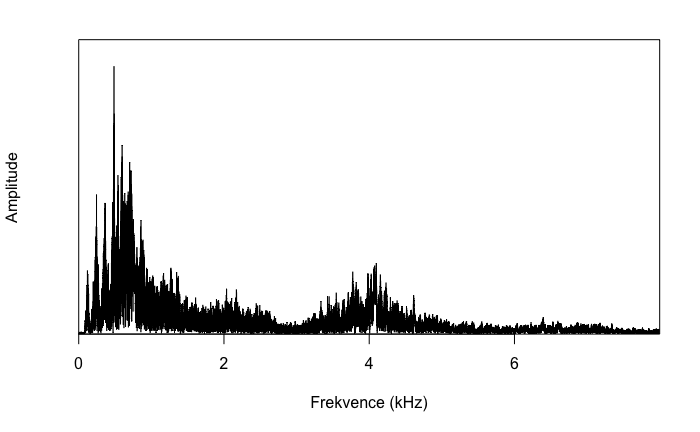

Spectrogram obohacený o decibely.

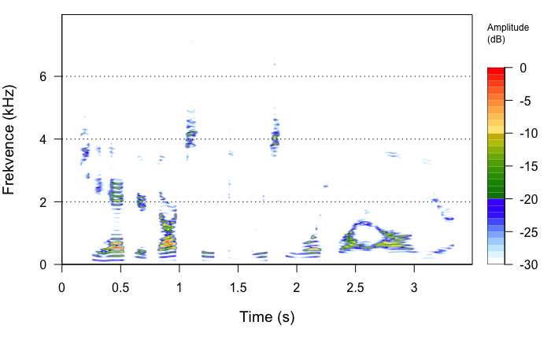

### Databáze řeči TIMIT

TIMIT Acoustic-Phonetic Continous Speech Corpus (LDC) je databáze čtené řeči, která je primárně určena pro studium akusticko-fonetických jevů a pro testování systémů automatického rozpoznávání řeči. Svým objemem lze TIMIT zařadit do kategorie korpusů s velkým počtem řečníků (obvykle obsahují řeč od více než 50 řečníků). Na této databázi se podílelo 630 osob, přičemž každá přispěla přečtením a nahráním 10 foneticky bohatých vět. Nahrávky jsou v osmi hlavních dialektech americké angličtiny. Struktura tohoto korpusu je poměrně specifická. Každá nahrávka je charakterizována následujícími soubory:

- zvukový soubor ve formátu PCM,
- soubor s příponou .PHN obsahující časový fonetický přepis, zapsaný v abecedě Arpabet,
- textový soubor obsahující přepis nahrávky ve formátu .TXT,
- soubor s příponou .LAB obsahující přepis slov jejich vymezením v nahrávce,
- soubor s příponou .WRD obsahující s vymezení jednotlivých slov v nahrávce.

#### Poznámka pro vývoj (struktura CSV)

- .WRD - od do slovo
- .PHM - od do phoném
- .TXT - od do věta

## Postup implementace algoritmu pro detekci mluvené řeči ve zvukové stopě

### 1. Je nutné projít databázi TIMIT a načíst zvuk + informace o stopě

```r
play(wavFiles[0])
```

```
Error in (function (classes, fdef, mtable)  :
  unable to find an inherited method for function ‘play’ for signature ‘"list"’
```

### 2. Definice funkce pro rozdělení zvukové stopy na části po kroku v milisekundách

### 3. Definice funkce pro rozdělení textu na části na základě zvukové stopy po kroku v milisekundách

### 4. Definice samotné mapy a mapyZvuku

### 5. Definice délky kroku v milisekundách + rozdělení veškerých informací a zvukových stop na slova a krátké zvukové úseky

|  | V1 | V2 | V3 | V4 |
| --- | --- | --- | --- | --- |
| 1 | NA | 16000 | 16 | 1 |
| 2 | NA | 16000 | 16 | 1 |
| 3 | NA | 16000 | 16 | 1 |
| 4 | NA | 16000 | 16 | 1 |
| 5 | NA | 16000 | 16 | 1 |
| 6 | NA | 16000 | 16 | 1 |
| 7 | NA | 16000 | 16 | 1 |
| 8 | she | 16000 | 16 | 1 |
| 9 | she | 16000 | 16 | 1 |
| 10 | she | 16000 | 16 | 1 |

[output cut: 990 more lines]

### 6. Výběr náhodného úseku a práce s ním (přehrání úseku)

|  | V1 | V2 | V3 | V4 |
| --- | --- | --- | --- | --- |
| 63 | NA | 16000 | 16 | 2 |

### 7. Hledání slova

```r
print(which(is.na(mapa$V1)))
```

```
   [1]    1    2   60   61   62   63  110  111  112  113  163  164  165  166  167  206  207  208  209  210  217  249  250  251
  [25]  252  253  254  298  299  300  301  302  303  339  340  341  342  343  365  394  395  416  417  418  419  420  473  474
  [49]  475  476  503  556  557  558  559  560  561  562  563  564  565  566  567  623  624  625  626  627  628  629  677  678
  [73]  679  680  716  717  718  719  720  721  758  759  760  761  762  804  805  806  807  808  846  847  848  849  850  904
  [97]  905  906  907  908  909  910  911  912  913  914  915  916  917  918  993  994  995  996  997  998  999 1000 1001 1002
 [121] 1003 1004 1005 1006 1077 1078 1079 1080 1081 1082 1133 1134 1135 1136 1137 1138 1139 1192 1193 1194 1195 1196 1197 1239
 [145] 1240 1241 1242 1243 1244 1245 1289 1290 1291 1292 1293 1294 1346 1347 1348 1349 1350 1351 1352 1353 1394 1395 1396 1397
 [169] 1398 1437 1438 1439 1440 1441 1442 1490 1491 1492 1493 1494 1559 1560 1561 1562 1563 1588 1589 1590 1591 1592 1593 1633
 [193] 1634 1635 1636 1687 1700 1701 1702 1703 1704 1758 1759 1760 1761 1833 1834 1835 1836 1837 1878 1879 1880 1881 1882 1933
 [217] 1934 1935 1936 1937 1938 1939 1940 1941 1942 1943 1944 1945 1946 1996 1997 1998 1999 2000 2001 2055 2056 2057 2058 2059
 [241] 2110 2111 2112 2113 2114 2115 2188 2207 2208 2209 2210 2211 2212 2213 2214 2215 2216 2217 2218 2219 2220 2221 2252 2253
 [265] 2254 2255 2256 2257 2309 2323 2324 2325 2326 2327 2385 2386 2387 2388 2389 2390 2409 2444 2445 2446 2447 2448 2449 2450
 [289] 2486 2487 2488 2489 2490 2530 2531 2532 2533 2534 2535 2536 2537 2538 2539 2540 2541 2542 2598 2599 2600 2601 2602 2603
 [313] 2604 2605 2606 2652 2653 2654 2655 2656 2657 2658 2659 2660 2661 2662 2663 2664 2665 2709 2710 2711 2712 2756 2757 2758
 [337] 2759 2760 2761 2846 2847 2848 2849 2850 2851 2852 2853 2894 2895 2896 2897 2898 2899 2900 2901 2902 2903 2904 2905 2906
```

[output cut: 28 more lines]

### 8. Matice přechodu

Definuji si matici přechodu mezi stavy HLAS a TICHO. Jaká je pravděpodobnost přechodu ze stavu TICHO do stavu HLAS.

1 TICHO 2 HLAS

```r
print(maticePrechodu)
```

```
           [,1]       [,2]
[1,] 0.99189342 0.00810658
[2,] 0.01212178 0.98787822
```

### 9. Rozdělení zvukových částí do clusterů

Zkategorizuji části úseků do clusteru pomocí metody kmeans

```r
print(maticePravdepodobnostiVystupu)
```

```
            [,1]        [,2]        [,3]        [,4]        [,5]         [,6]       [,7]      [,8]       [,9]       [,10]
[1,] 0.009946442 0.006885998 0.009946442 0.005355777 0.002295333 0.0000000000 0.00841622 0.8829380 0.02295333 0.002295333
[2,] 0.009447166 0.003498950 0.013412643 0.011896431 0.003382319 0.0008164217 0.01119664 0.8460462 0.03230697 0.003732214
          [,11]       [,12]       [,13]       [,14]        [,15]       [,16]
[1,] 0.02601377 0.005355777 0.009181331 0.001530222 0.0038255547 0.003060444
[2,] 0.03242361 0.010613483 0.013062748 0.001399580 0.0009330534 0.005831584
```

### 10. Příprava modelu HMM

```r
print(hmm)
```

```
$States
[1] "0" "1"

$Symbols
 [1]  1  2  3  4  5  6  7  8  9 10 11 12 13 14 15 16

$startProbs
  0   1
0.5 0.5

$transProbs
    to
from          0          1
   0 0.99189342 0.00810658
   1 0.01212178 0.98787822

$emissionProbs
      symbols
states           1           2           3           4           5            6          7         8          9          10
     0 0.009946442 0.006885998 0.009946442 0.005355777 0.002295333 0.0000000000 0.00841622 0.8829380 0.02295333 0.002295333
     1 0.009447166 0.003498950 0.013412643 0.011896431 0.003382319 0.0008164217 0.01119664 0.8460462 0.03230697 0.003732214
      symbols
states         11          12          13          14           15          16
     0 0.02601377 0.005355777 0.009181331 0.001530222 0.0038255547 0.003060444
     1 0.03242361 0.010613483 0.013062748 0.001399580 0.0009330534 0.005831584
```

### 11. Viterbi algoritmus

Tento algoritmus slouží k vyhledání maximálně pravděpodobné sekvence stavů modelu M, která generovala pozorování P, a také k výpočtu její pravděpodobnosti. Definujme pravděpodobnost cesty modelem, která vychází z počá tečního stavu a končí ve stavu j v čase t a přitom generuje řečové vektory p1, . . . , pt. Hledání požadované sekvence stavů si lze představit jako hledání cesty v mřížce. Na svislé ose jsou vyneseny jednotlivé stavy Markovova modelu a na vodorovné ose jsou časové úseky 1,…,T.

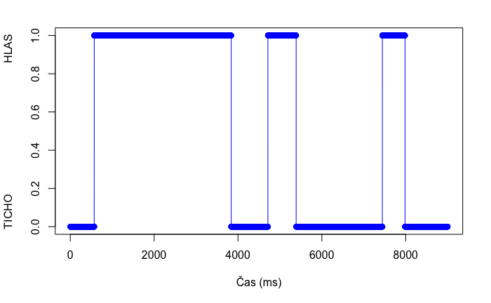